# DNAmAge Clocks

## Clocks

Horvath has sent generated many clocks, for this project relevant clocks begin with prefix ‘DNAmAgeClock’. These are:

- DNAmAgeClockCortex
- DNAmAgeClockBrain
- DNAmAgeClockPan
- DNAmAgeClockLiver
- DNAmAgeClockBlood
- DNAmAgeClockHeart

```r
library(tidyr)
library(dplyr)
library(lme4)
library(nlme)
library(mltools)

library(kableExtra)
library(ggplot2)
library(gridExtra)

## read data in
load("/gpfs/ts0/projects/Research_Project-191406/Aisha/data/Array/Normalised_Data_Sesame.rdat") #load this in to have passed QC samples only as samplesheet has failed samples
pheno <- QCmetrics[which(QCmetrics$Tissue %in% c("CortexEntorhinalis", "Hippocampus")),] #take tissue samples further


samplesheet <- read.csv("/gpfs/ts0/projects/Research_Project-191406/Horvath/MammalianArrayNormalizationTools/Clocks/OutputMouseClocks.csv", header = T,stringsAsFactors = F)
samplesheet <- samplesheet[,c(1:50)] #filter unnecessary values
samplesheet <- samplesheet[which(samplesheet$Basename %in% pheno$Basename),] #filter to just tissue samples to join with pathology data
samplesheet$SampleID <- gsub(".*_", "",samplesheet$ExternalSampleID)
## Add pathology data in
J20_pathdata <- read.csv("/gpfs/ts0/projects/Research_Project-191406/Aisha/data/Array/J20_coldata_VertebrateArray.csv", header = T, stringsAsFactors = F)
rTg4510_pathdata <- read.csv("/gpfs/ts0/projects/Research_Project-191406/Aisha/data/Array/Tg4510_coldata_VertebrateArray.csv", header = T, stringsAsFactors = F)

#Pathology knows which samples are paired so add the column for it now
for(i in 1:nrow(J20_pathdata)){
  J20_pathdata[i, "MouseID"] <- paste("J20_M", i, sep="")
}

for(i in 1:nrow(rTg4510_pathdata)){
  rTg4510_pathdata[i, "MouseID"] <- paste("rTg4510_M", i, sep="")
}

#split the tissue and model into sep data
J20_ecx <- J20_pathdata[,c("Sample_ID_ECX","Mouse_ID","Genotype","Age_months","Group_ID","Histology_no","Pathology_ECX", "MouseID" )]
colnames(J20_ecx) <- c("SampleID","Mouse_ID","Genotype","Age_months","Group_ID","Histology_no","Pathology", "MouseID")
J20_hip <- J20_pathdata[,c("Sample_ID_HIP","Mouse_ID","Genotype","Age_months","Group_ID","Histology_no","Pathology_HIP", "MouseID")]
colnames(J20_hip) <- c("SampleID","Mouse_ID","Genotype","Age_months","Group_ID","Histology_no","Pathology", "MouseID")

rTg4510_ecx <- rTg4510_pathdata[,c("Sample_ID_ECX","Mouse_ID","Genotype","Age_months","Group_ID","Histology_no","Pathology_ECX", "MouseID")]
colnames(rTg4510_ecx) <- c("SampleID","Mouse_ID","Genotype","Age_months","Group_ID","Histology_no","Pathology", "MouseID")
rTg4510_hip <- rTg4510_pathdata[,c("Sample_ID_HIP","Mouse_ID","Genotype","Age_months","Group_ID","Histology_no","Pathology_HIP", "MouseID")]
colnames(rTg4510_hip) <- c("SampleID","Mouse_ID","Genotype","Age_months","Group_ID","Histology_no","Pathology", "MouseID")

pathology <- rbind(J20_ecx, J20_hip, rTg4510_ecx, rTg4510_hip)
samplesheet <- merge(samplesheet, pathology, by = "SampleID")
samplesheet <- samplesheet[,-53]
colnames(samplesheet)[colnames(samplesheet) == 'Genotype.x'] <- 'Genotype'

samplesheet <- separate(data = samplesheet, col = Basename,
                        into = c("Chip", "Chip_Position"), sep="_")
samplesheet$Genotype <- factor(samplesheet$Genotype, levels = c("WT","TG"))
```

```r
############### Functions for plots as it is repetitive and keep mislabelling



#Plots for WT samples
plotWTSamples <- function(dat, clocks, tissue, model){
  dat2 <- dat[which(dat$Genotype == "WT"),]
  par(mfrow = c(2,3))
  for(clock in clocks){
    corr <- cor(dat2$Age, dat2[, clock])
    err <- rmse(preds = dat2[, clock], actuals = dat2$Age)
    plot(dat2$Age, dat2[, clock], col = dat2$GenotypeCol,
         xlab = "Age", ylab = as.character(clock),
         main = paste(paste(model, tissue, sep = " "), clock, sep = " - "))
    mtext(paste("cor = ", signif(corr,3)), side = 3, adj = 1)
    mtext(paste("rmse = ", signif(err,3)), side = 3, adj = 0)
    abline(0,1)
  }
}

#Plots for TGs and WTs samples
plotSamples <- function(dat, clocks, tissue, model){
  par(mfrow = c(2,3))
  for(clock in clocks){
    corr <- cor(dat$Age, dat[, clock])
    err <- rmse(preds = dat[, clock], actuals = dat$Age)
    plot(dat$Age, dat[, clock], col = dat$GenotypeCol,
         xlab = "Age", ylab = as.character(clock),
         main = paste(paste(model, tissue, sep = " "), clock, sep = " - "))
    mtext(paste("cor = ", signif(corr,3)), side = 3, adj = 1)
    mtext(paste("rmse = ", signif(err,3)), side = 3, adj = 0)
    abline(0,1)
  }
}
```

## Models

Firstly, we will run two seperate models for predictors Genotype and Pathology. We can see below that the Cortex Clock works correlates best with WT and therefore will use the Cortex clock for both Entorhinalis Cortex and Hippocampus brain region. The models are:

$${DNAmAgeClockCortex } = {Genotype}$$
$${DNAmAgeClockCortex } = {Pathology}$$

```r
#create a results table
res <- matrix(NA, nrow = 8, ncol= 4)
colnames(res) <- c("rTg4510_ECX", "rTg4510_HIP", "J20_ECX", "J20_HIP")
rownames(res) <- c("Genotype.Intercept", "Genotype.Beta", "Genotype.SE", "Genotype.P",
                   "Pathology.Intercept","Pathology.Beta", "Pathology.SE", "Pathology.P")
```

### ECX rTg4510

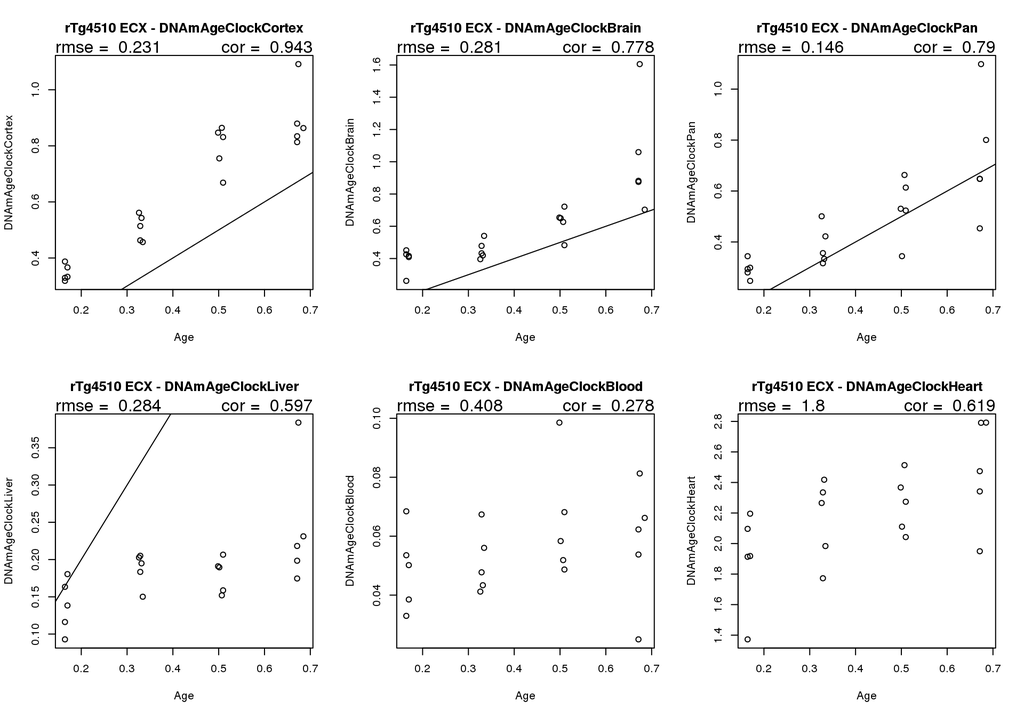

```r
########################################### filter for ecx rTg4510
Tissue <- "CortexEntorhinalis"
Model  <- "rTg4510"
TG_colour <- "#00AEC9"

dat <- samplesheet[which(samplesheet$Tissue == Tissue & samplesheet$AD_model == Model),]
dat$Genotype <- factor(dat$Genotype, levels = c("WT","TG"))
dat$GenotypeCol <-  ifelse(dat$Genotype == "WT", "black", TG_colour)

## make a plot of actual age and DNAmAge for each type
clocks <- c("DNAmAgeClockCortex", "DNAmAgeClockBrain" ,
            "DNAmAgeClockPan","DNAmAgeClockLiver",
            "DNAmAgeClockBlood","DNAmAgeClockHeart")

## WT samples only
plotWTSamples(dat, clocks, tissue = "ECX", model = "rTg4510")
```

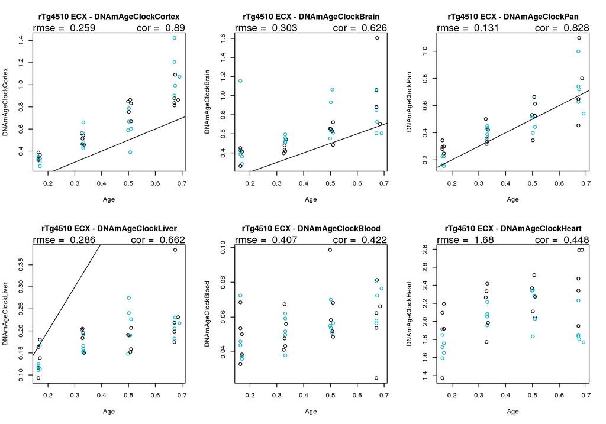

```r
## all samples WT and TGs
plotSamples(dat, clocks, tissue = "ECX", model = "rTg4510")
```

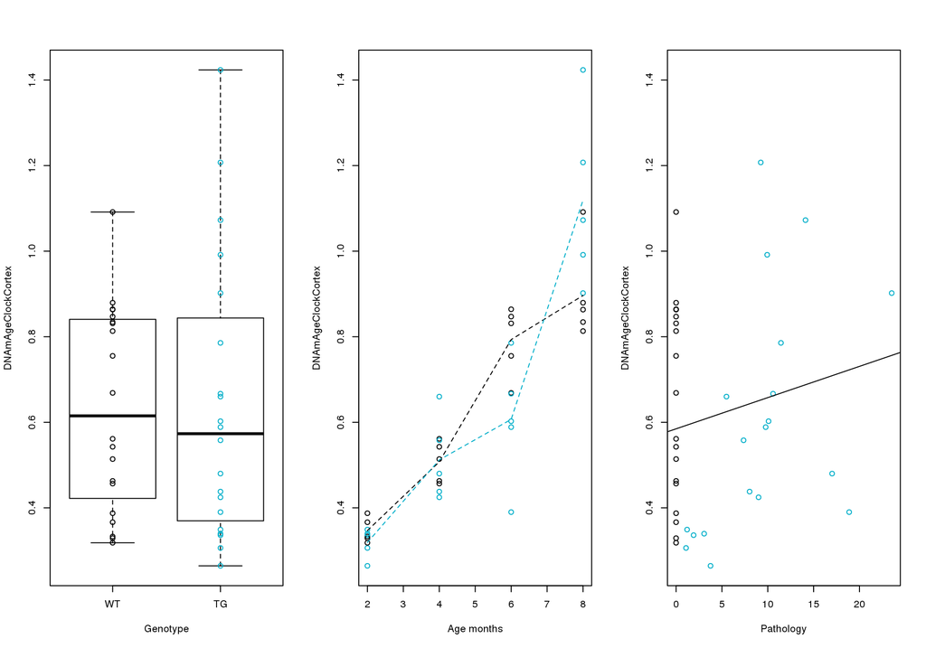

```r
## DNAmAge and terms
par(mfrow = c(1,3))
plot(dat$Genotype, dat$DNAmAgeClockCortex,
     xlab = "Genotype", ylab = "DNAmAgeClockCortex")
points(dat$Genotype, dat$DNAmAgeClockCortex, col = dat$GenotypeCol)

ages <- sort(unique(dat$Age_months))
means_WT <- c()
means_TG <- c()
for (age in unique(dat$Age_months)) {
  means_WT <- c(means_WT, mean(dat[which(dat$Age_months==age & dat$Genotype=="WT"),"DNAmAgeClockCortex"]))
  means_TG <- c(means_TG, mean(dat[which(dat$Age_months==age & dat$Genotype=="TG"),"DNAmAgeClockCortex"]))
}
plot(dat$Age_months, dat$DNAmAgeClockCortex, col = dat$GenotypeCol,
     xlab = "Age months", ylab = "DNAmAgeClockCortex")
lines(ages, means_WT, lty=2, col="black")
lines(ages, means_TG, lty=2, col=TG_colour)

plot(dat$Pathology, dat$DNAmAgeClockCortex, col = dat$GenotypeCol,
     xlab = "Pathology", ylab = "DNAmAgeClockCortex")
abline(lm(DNAmAgeClockCortex ~  Pathology, data=dat))
```

```r
## Now run the linear models
lmmodel <- lm(DNAmAgeClockCortex ~  Genotype, data=dat)
summary(lmmodel)$coef
```

```
##                Estimate Std. Error    t value     Pr(>|t|)
## (Intercept) 0.636001285 0.06381197 9.96680147 3.744406e-12
## GenotypeTG  0.003334229 0.09024376 0.03694692 9.707207e-01
```

```r
res[1,1] <- summary(lmmodel)$coef["(Intercept)",1]
res[2,1] <- summary(lmmodel)$coef["GenotypeTG",1]
res[3,1] <- summary(lmmodel)$coef["GenotypeTG",2]
res[4,1] <- summary(lmmodel)$coef["GenotypeTG",4]

lmmodel <- lm(DNAmAgeClockCortex ~  Pathology, data=dat)
summary(lmmodel)$coef
```

```
##                Estimate  Std. Error   t value     Pr(>|t|)
## (Intercept) 0.584727702 0.052373163 11.164644 4.396160e-13
## Pathology   0.007299486 0.006669927  1.094388 2.812595e-01
```

```r
res[5,1] <- summary(lmmodel)$coef["(Intercept)",1]
res[6,1] <- summary(lmmodel)$coef["Pathology",1]
res[7,1] <- summary(lmmodel)$coef["Pathology",2]
res[8,1] <- summary(lmmodel)$coef["Pathology",4]
```

### HIP rTg4510

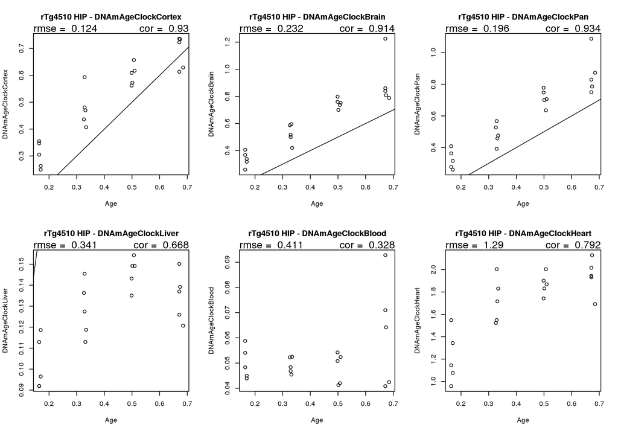

```r
############################################ filter for hip rTg4510
Tissue <- "Hippocampus"
Model  <- "rTg4510"
TG_colour <- "#00AEC9"

dat <- samplesheet[which(samplesheet$Tissue == Tissue & samplesheet$AD_model == Model),]
dat$Genotype <- factor(dat$Genotype, levels = c("WT","TG"))
dat$GenotypeCol <-  ifelse(dat$Genotype == "WT", "black", TG_colour)

## make a plot of actual age and DNAmAge for each type
clocks <- c("DNAmAgeClockCortex", "DNAmAgeClockBrain" ,
            "DNAmAgeClockPan","DNAmAgeClockLiver",
            "DNAmAgeClockBlood","DNAmAgeClockHeart")

## WT samples only
plotWTSamples(dat, clocks, tissue = "HIP", model = "rTg4510")
```

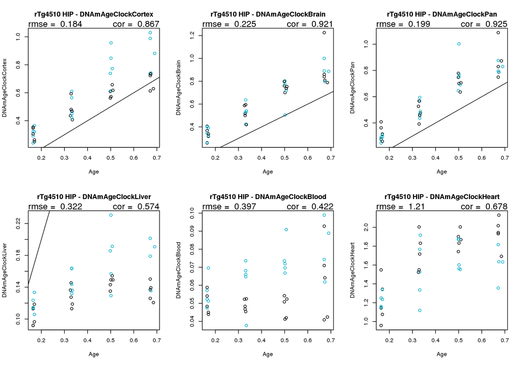

```r
## all samples WT and TGs
plotSamples(dat, clocks, tissue = "HIP", model = "rTg4510")
```

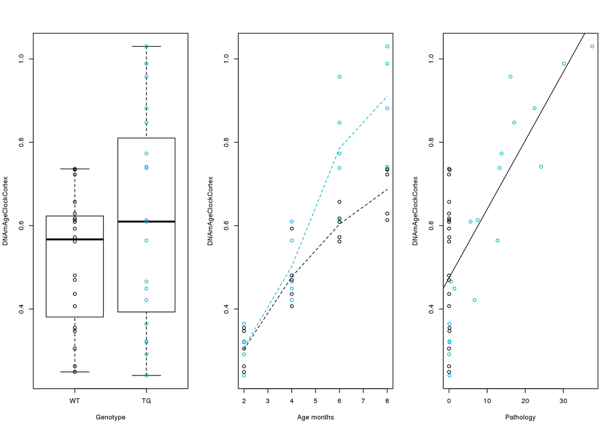

```r
## DNAmAge and terms
par(mfrow = c(1,3))
plot(dat$Genotype, dat$DNAmAgeClockCortex,
     xlab = "Genotype", ylab = "DNAmAgeClockCortex")
points(dat$Genotype, dat$DNAmAgeClockCortex, col = dat$GenotypeCol)

ages <- sort(unique(dat$Age_months))
means_WT <- c()
means_TG <- c()
for (age in unique(dat$Age_months)) {
  means_WT <- c(means_WT, mean(dat[which(dat$Age_months==age & dat$Genotype=="WT"),"DNAmAgeClockCortex"]))
  means_TG <- c(means_TG, mean(dat[which(dat$Age_months==age & dat$Genotype=="TG"),"DNAmAgeClockCortex"]))
}
plot(dat$Age_months, dat$DNAmAgeClockCortex, col = dat$GenotypeCol,
     xlab = "Age months", ylab = "DNAmAgeClockCortex")
lines(ages, means_WT, lty=2, col="black")
lines(ages, means_TG, lty=2, col=TG_colour)

plot(dat$Pathology, dat$DNAmAgeClockCortex, col = dat$GenotypeCol,
     xlab = "Pathology", ylab = "DNAmAgeClockCortex")
abline(lm(DNAmAgeClockCortex ~  Pathology, data=dat))
```

```r
## Now run the linear models
lmmodel <- lm(DNAmAgeClockCortex ~  Genotype , data=dat)
summary(lmmodel)$coef
```

```
##               Estimate Std. Error   t value     Pr(>|t|)
## (Intercept) 0.51790974 0.04717428 10.978646 3.389682e-13
## GenotypeTG  0.09371251 0.06758663  1.386554 1.738762e-01
```

```r
res[1,2] <- summary(lmmodel)$coef["(Intercept)",1]
res[2,2] <- summary(lmmodel)$coef["GenotypeTG",1]
res[3,2] <- summary(lmmodel)$coef["GenotypeTG",2]
res[4,2] <- summary(lmmodel)$coef["GenotypeTG",4]

lmmodel <- lm(DNAmAgeClockCortex ~  Pathology, data=dat)
summary(lmmodel)$coef
```

```
##               Estimate  Std. Error   t value     Pr(>|t|)
## (Intercept) 0.47461674 0.026854456 17.673668 1.256366e-19
## Pathology   0.01647036 0.002464706  6.682486 7.536086e-08
```

```r
res[5,2] <- summary(lmmodel)$coef["(Intercept)",1]
res[6,2] <- summary(lmmodel)$coef["Pathology",1]
res[7,2] <- summary(lmmodel)$coef["Pathology",2]
res[8,2] <- summary(lmmodel)$coef["Pathology",4]
```

### ECX J20

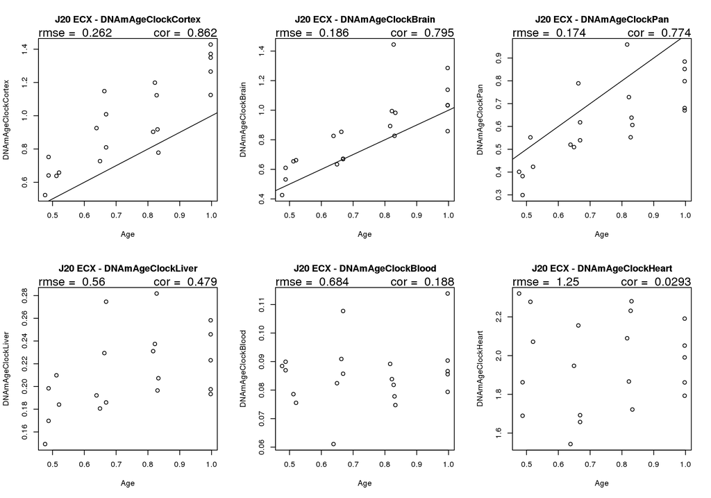

```r
############################################ filter for ecx J20
Tissue <- "CortexEntorhinalis"
Model  <- "J20"
TG_colour <- "#FF5A62"

dat <- samplesheet[which(samplesheet$Tissue == Tissue & samplesheet$AD_model == Model),]
dat$Genotype <- factor(dat$Genotype, levels = c("WT","TG"))
dat$GenotypeCol <-  ifelse(dat$Genotype == "WT", "black", TG_colour)

## make a plot of actual age and DNAmAge for each type
clocks <- c("DNAmAgeClockCortex", "DNAmAgeClockBrain" ,
            "DNAmAgeClockPan","DNAmAgeClockLiver",
            "DNAmAgeClockBlood","DNAmAgeClockHeart")
## WT samples only
plotWTSamples(dat, clocks, tissue = "ECX", model = "J20")
```

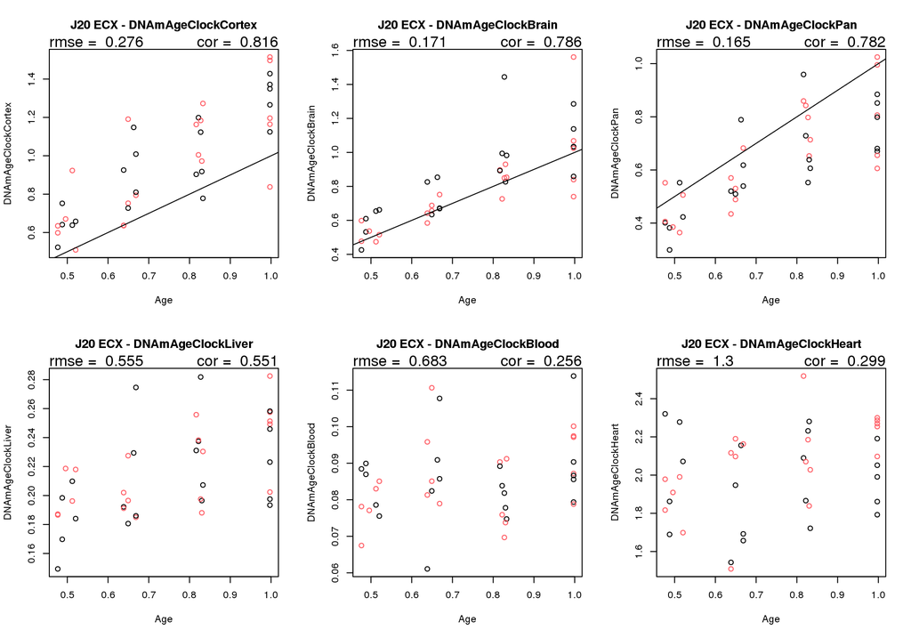

```r
## all samples WT and TGs
plotSamples(dat, clocks, tissue = "ECX", model = "J20")
```

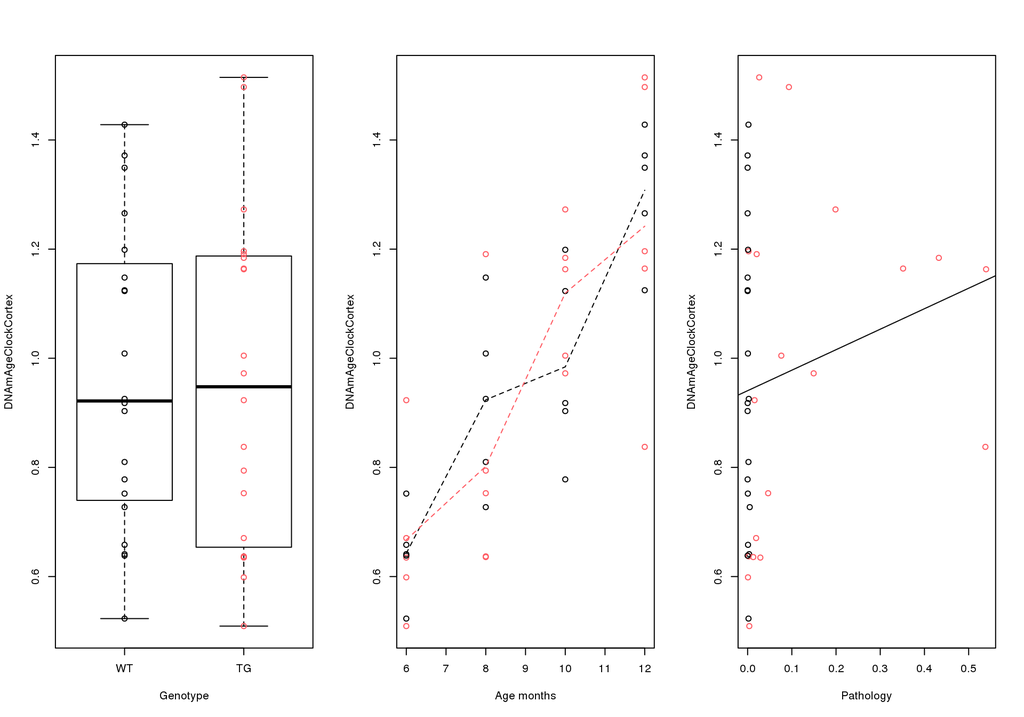

```r
## DNAmAge and terms
par(mfrow = c(1,3))
plot(dat$Genotype, dat$DNAmAgeClockCortex,
     xlab = "Genotype", ylab = "DNAmAgeClockCortex")
points(dat$Genotype, dat$DNAmAgeClockCortex, col = dat$GenotypeCol)

ages <- sort(unique(dat$Age_months))
means_WT <- c()
means_TG <- c()
for (age in unique(dat$Age_months)) {
  means_WT <- c(means_WT, mean(dat[which(dat$Age_months==age & dat$Genotype=="WT"),"DNAmAgeClockCortex"]))
  means_TG <- c(means_TG, mean(dat[which(dat$Age_months==age & dat$Genotype=="TG"),"DNAmAgeClockCortex"]))
}
plot(dat$Age_months, dat$DNAmAgeClockCortex, col = dat$GenotypeCol,
     xlab = "Age months", ylab = "DNAmAgeClockCortex")
lines(ages, means_WT, lty=2, col="black")
lines(ages, means_TG, lty=2, col=TG_colour)

plot(dat$Pathology, dat$DNAmAgeClockCortex, col = dat$GenotypeCol,
     xlab = "Pathology", ylab = "DNAmAgeClockCortex")
abline(lm(DNAmAgeClockCortex ~  Pathology, data=dat))
```

```r
## Now run the linear models
lmmodel <- lm(DNAmAgeClockCortex ~  Genotype, data=dat)
summary(lmmodel)$coef
```

```
##                 Estimate Std. Error     t value     Pr(>|t|)
## (Intercept)  0.964615273 0.06474749 14.89811031 1.881622e-17
## GenotypeTG  -0.006945085 0.09156678 -0.07584721 9.399386e-01
```

```r
res[1,3] <- summary(lmmodel)$coef["(Intercept)",1]
res[2,3] <- summary(lmmodel)$coef["GenotypeTG",1]
res[3,3] <- summary(lmmodel)$coef["GenotypeTG",2]
res[4,3] <- summary(lmmodel)$coef["GenotypeTG",4]


lmmodel <- lm(DNAmAgeClockCortex ~  Pathology, data=dat)
summary(lmmodel)$coef
```

```
##              Estimate Std. Error   t value     Pr(>|t|)
## (Intercept) 0.9406050 0.05057937 18.596612 2.300545e-20
## Pathology   0.3755498 0.32032650  1.172397 2.485312e-01
```

```r
res[5,3] <- summary(lmmodel)$coef["(Intercept)",1]
res[6,3] <- summary(lmmodel)$coef["Pathology",1]
res[7,3] <- summary(lmmodel)$coef["Pathology",2]
res[8,3] <- summary(lmmodel)$coef["Pathology",4]
```

### HIP J20

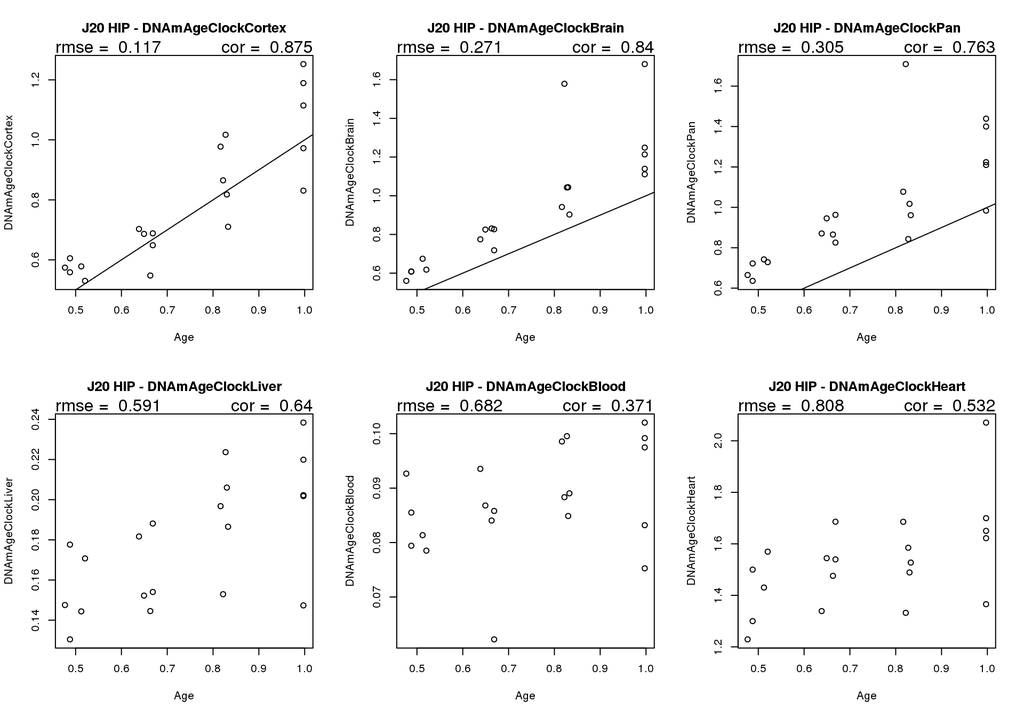

```r
############################################ filter for hip J20
Tissue <- "Hippocampus"
Model  <- "J20"
TG_colour <- "#FF5A62"

dat <- samplesheet[which(samplesheet$Tissue == Tissue & samplesheet$AD_model == Model),]
dat$Genotype <- factor(dat$Genotype, levels = c("WT","TG"))
dat$GenotypeCol <-  ifelse(dat$Genotype == "WT", "black", TG_colour)

## make a plot of actual age and DNAmAge for each type
clocks <- c("DNAmAgeClockCortex", "DNAmAgeClockBrain" ,
            "DNAmAgeClockPan","DNAmAgeClockLiver",
            "DNAmAgeClockBlood","DNAmAgeClockHeart")

## WT samples only
plotWTSamples(dat, clocks, tissue = "HIP", model = "J20")
```

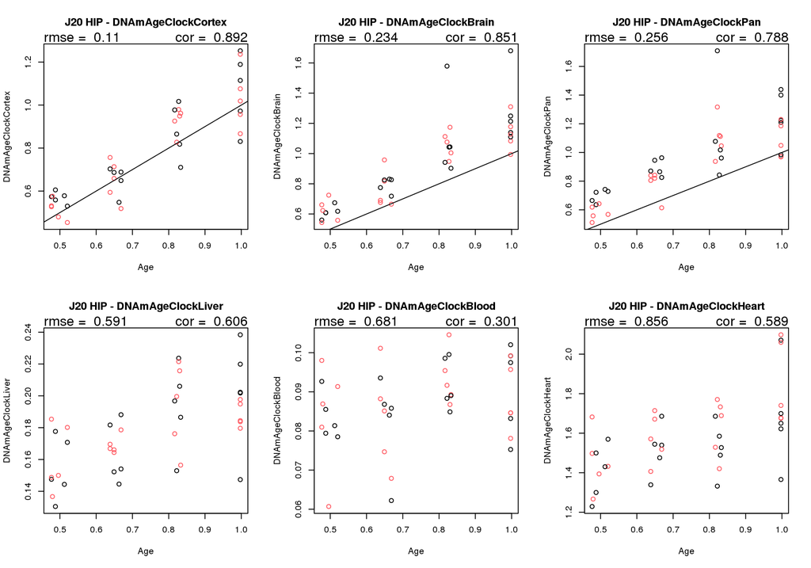

```r
## all samples WT and TGs
plotSamples(dat, clocks, tissue = "HIP", model = "J20")
```

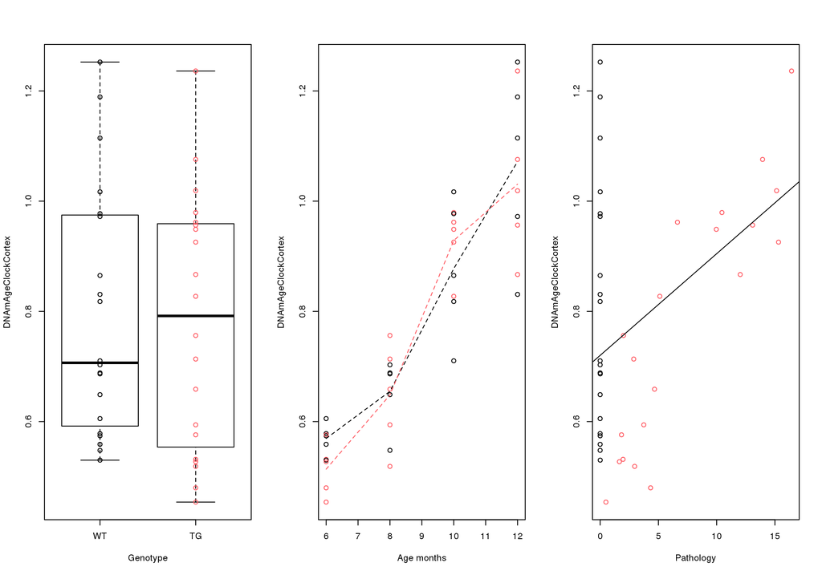

```r
## DNAmAge and terms
par(mfrow = c(1,3))
plot(dat$Genotype, dat$DNAmAgeClockCortex,
     xlab = "Genotype", ylab = "DNAmAgeClockCortex")
points(dat$Genotype, dat$DNAmAgeClockCortex, col = dat$GenotypeCol)

ages <- sort(unique(dat$Age_months))
means_WT <- c()
means_TG <- c()
for (age in unique(dat$Age_months)) {
  means_WT <- c(means_WT, mean(dat[which(dat$Age_months==age & dat$Genotype=="WT"),"DNAmAgeClockCortex"]))
  means_TG <- c(means_TG, mean(dat[which(dat$Age_months==age & dat$Genotype=="TG"),"DNAmAgeClockCortex"]))
}
plot(dat$Age_months, dat$DNAmAgeClockCortex, col = dat$GenotypeCol,
     xlab = "Age months", ylab = "DNAmAgeClockCortex")
lines(ages, means_WT, lty=2, col="black")
lines(ages, means_TG, lty=2, col=TG_colour)

plot(dat$Pathology, dat$DNAmAgeClockCortex, col = dat$GenotypeCol,
     xlab = "Pathology", ylab = "DNAmAgeClockCortex")
abline(lm(DNAmAgeClockCortex ~  Pathology, data=dat))
```

```r
## Now run the linear models
lmmodel <- lm(DNAmAgeClockCortex ~  Genotype, data=dat)
summary(lmmodel)$coef
```

```
##                Estimate Std. Error   t value     Pr(>|t|)
## (Intercept)  0.79338737 0.05089767 15.587892 4.266253e-18
## GenotypeTG  -0.01306023 0.07198017 -0.181442 8.569850e-01
```

```r
res[1,4] <- summary(lmmodel)$coef["(Intercept)",1]
res[2,4] <- summary(lmmodel)$coef["GenotypeTG",1]
res[3,4] <- summary(lmmodel)$coef["GenotypeTG",2]
res[4,4] <- summary(lmmodel)$coef["GenotypeTG",4]


lmmodel <- lm(DNAmAgeClockCortex ~  Pathology, data=dat)
summary(lmmodel)$coef
```

```
##              Estimate  Std. Error   t value     Pr(>|t|)
## (Intercept) 0.7201065 0.039512149 18.224939 2.229594e-20
## Pathology   0.0184542 0.006230825  2.961758 5.250146e-03
```

```r
res[5,4] <- summary(lmmodel)$coef["(Intercept)",1]
res[6,4] <- summary(lmmodel)$coef["Pathology",1]
res[7,4] <- summary(lmmodel)$coef["Pathology",2]
res[8,4] <- summary(lmmodel)$coef["Pathology",4]
```

```r
resGenotype <- res[1:4,]
kable(resGenotype) %>%
  kable_styling() %>%
  scroll_box(width = "100%", height = "200px")
```

|  | rTg4510_ECX | rTg4510_HIP | J20_ECX | J20_HIP |
| --- | --- | --- | --- | --- |
| Genotype.Intercept | 0.6360013 | 0.5179097 | 0.9646153 | 0.7933874 |
| Genotype.Beta | 0.0033342 | 0.0937125 | -0.0069451 | -0.0130602 |
| Genotype.SE | 0.0902438 | 0.0675866 | 0.0915668 | 0.0719802 |
| Genotype.P | 0.9707207 | 0.1738762 | 0.9399386 | 0.8569850 |

```r
write.csv(resGenotype, "DNAmAgeClockCortex_Genotype_results.csv")
```

```r
resPathology <- res[5:8,]

kable(resPathology) %>%
  kable_styling() %>%
  scroll_box(width = "100%", height = "200px")
```

|  | rTg4510_ECX | rTg4510_HIP | J20_ECX | J20_HIP |
| --- | --- | --- | --- | --- |
| Pathology.Intercept | 0.5847277 | 0.4746167 | 0.9406050 | 0.7201065 |
| Pathology.Beta | 0.0072995 | 0.0164704 | 0.3755498 | 0.0184542 |
| Pathology.SE | 0.0066699 | 0.0024647 | 0.3203265 | 0.0062308 |
| Pathology.P | 0.2812595 | 0.0000001 | 0.2485312 | 0.0052501 |

```r
write.csv(resPathology, "DNAmAgeClockCortex_Pathology_results.csv")
```

## Full Models

### Genotype*Age

$${DNAmAgeClockCortex } = {Genotype + Age + Genotype*Age}$$

```r
################ DNAmAge ~ Genotype + Age + Genotype*Age,

#create a results table
res <- matrix(NA, nrow = 10, ncol= 4)
colnames(res) <- c("rTg4510_ECX", "rTg4510_HIP", "J20_ECX", "J20_HIP")
rownames(res) <- c("Intercept", "GenotypeTG.Beta", "GenotypeTG.SE", "GenotypeTG.P",
                   "Age.Beta","Age.SE", "Age.P",
                   "GenotypeTG.Age.Beta","GenotypeTG.Age.SE", "GenotypeTG.Age.P")

#rTg4510 ECX
Tissue <- "CortexEntorhinalis"
Model  <- "rTg4510"
dat <- samplesheet[which(samplesheet$Tissue == Tissue & samplesheet$AD_model == Model),]

lmodel <- lm(DNAmAgeClockCortex ~ Genotype + Age + Genotype*Age, data=dat)

res[1,1] <- summary(lmodel)$coef["(Intercept)",1]
res[2,1] <- summary(lmodel)$coef["GenotypeTG",1]
res[3,1] <- summary(lmodel)$coef["GenotypeTG",2]
res[4,1] <- summary(lmodel)$coef["GenotypeTG",4]


res[5,1] <- summary(lmodel)$coef["Age",1]
res[6,1] <- summary(lmodel)$coef["Age",2]
res[7,1] <- summary(lmodel)$coef["Age",4]


res[8,1] <- summary(lmodel)$coef["GenotypeTG:Age",1]
res[9,1] <- summary(lmodel)$coef["GenotypeTG:Age",2]
res[10,1] <- summary(lmodel)$coef["GenotypeTG:Age",4]

#rTg4510 HIP
Tissue <- "Hippocampus"
Model  <- "rTg4510"
dat <- samplesheet[which(samplesheet$Tissue == Tissue & samplesheet$AD_model == Model),]

lmodel <- lm(DNAmAgeClockCortex ~ Genotype + Age + Genotype*Age, data=dat)

res[1,2] <- summary(lmodel)$coef["(Intercept)",1]
res[2,2] <- summary(lmodel)$coef["GenotypeTG",1]
res[3,2] <- summary(lmodel)$coef["GenotypeTG",2]
res[4,2] <- summary(lmodel)$coef["GenotypeTG",4]

res[5,2] <- summary(lmodel)$coef["Age",1]
res[6,2] <- summary(lmodel)$coef["Age",2]
res[7,2] <- summary(lmodel)$coef["Age",4]

res[8,2] <- summary(lmodel)$coef["GenotypeTG:Age",1]
res[9,2] <- summary(lmodel)$coef["GenotypeTG:Age",2]
res[10,2] <- summary(lmodel)$coef["GenotypeTG:Age",4]

#J20 ECX
Tissue <- "CortexEntorhinalis"
Model  <- "J20"
dat <- samplesheet[which(samplesheet$Tissue == Tissue & samplesheet$AD_model == Model),]

lmodel <- lm(DNAmAgeClockCortex ~ Genotype + Age + Genotype*Age, data=dat)

res[1,3] <- summary(lmodel)$coef["(Intercept)",1]
res[2,3] <- summary(lmodel)$coef["GenotypeTG",1]
res[3,3] <- summary(lmodel)$coef["GenotypeTG",2]
res[4,3] <- summary(lmodel)$coef["GenotypeTG",4]

res[5,3] <- summary(lmodel)$coef["Age",1]
res[6,3] <- summary(lmodel)$coef["Age",2]
res[7,3] <- summary(lmodel)$coef["Age",4]

res[8,3] <- summary(lmodel)$coef["GenotypeTG:Age",1]
res[9,3] <- summary(lmodel)$coef["GenotypeTG:Age",2]
res[10,3] <- summary(lmodel)$coef["GenotypeTG:Age",4]


#J20 HIP
Tissue <- "Hippocampus"
Model  <- "J20"
dat <- samplesheet[which(samplesheet$Tissue == Tissue & samplesheet$AD_model == Model),]

lmodel <- lm(DNAmAgeClockCortex ~ Genotype + Age + Genotype*Age, data=dat)

res[1,4] <- summary(lmodel)$coef["(Intercept)",1]
res[2,4] <- summary(lmodel)$coef["GenotypeTG",1]
res[3,4] <- summary(lmodel)$coef["GenotypeTG",2]
res[4,4] <- summary(lmodel)$coef["GenotypeTG",4]

res[5,4] <- summary(lmodel)$coef["Age",1]
res[6,4] <- summary(lmodel)$coef["Age",2]
res[7,4] <- summary(lmodel)$coef["Age",4]

res[8,4] <- summary(lmodel)$coef["GenotypeTG:Age",1]
res[9,4] <- summary(lmodel)$coef["GenotypeTG:Age",2]
res[10,4] <- summary(lmodel)$coef["GenotypeTG:Age",4]
```

```r
write.csv(res, "DNAmAgeClockCortex_GenotypeAgeInteraction_results.csv")

kable(res) %>%
  kable_styling() %>%
  scroll_box(width = "100%", height = "500px")
```

|  | rTg4510_ECX | rTg4510_HIP | J20_ECX | J20_HIP |
| --- | --- | --- | --- | --- |
| Intercept | 0.1591387 | 0.2045042 | 0.0477781 | 0.0276017 |
| GenotypeTG.Beta | -0.1346840 | -0.0962173 | 0.0024629 | -0.0386970 |
| GenotypeTG.SE | 0.0993887 | 0.0636652 | 0.2224952 | 0.1356664 |
| GenotypeTG.P | 0.1838207 | 0.1396888 | 0.9912290 | 0.7770977 |
| Age.Beta | 1.1379853 | 0.7488906 | 1.2316730 | 1.0287515 |
| Age.SE | 0.1527002 | 0.0970227 | 0.2059313 | 0.1263511 |
| Age.P | 0.0000000 | 0.0000000 | 0.0000007 | 0.0000000 |
| GenotypeTG.Age.Beta | 0.3284080 | 0.4915610 | -0.0088130 | 0.0401447 |
| GenotypeTG.Age.SE | 0.2159485 | 0.1406809 | 0.2902644 | 0.1771068 |
| GenotypeTG.Age.P | 0.1370531 | 0.0013099 | 0.9759460 | 0.8219629 |

### Pathology

$${DNAmAgeClockCortex } = {Genotype + Age + Pathology}$$

```r
################ DNAmAge ~ Genotype + Age + Genotype*Age,
#create a results table
res <- matrix(NA, nrow = 10, ncol= 4)
colnames(res) <- c("rTg4510_ECX", "rTg4510_HIP", "J20_ECX", "J20_HIP")
rownames(res) <- c("Intercept", "GenotypeTG.Beta", "GenotypeTG.SE", "GenotypeTG.P",
                   "Age.Beta","Age.SE", "Age.P",
                   "Pathology.Beta","Pathology.SE", "Pathology.P")

#rTg4510 ECX
Tissue <- "CortexEntorhinalis"
Model  <- "rTg4510"
dat <- samplesheet[which(samplesheet$Tissue == Tissue & samplesheet$AD_model == Model),]

lmodel <- lm(DNAmAgeClockCortex ~ Genotype + Age + Pathology, data=dat)

res[1,1] <- summary(lmodel)$coef["(Intercept)",1]
res[2,1] <- summary(lmodel)$coef["GenotypeTG",1]
res[3,1] <- summary(lmodel)$coef["GenotypeTG",2]
res[4,1] <- summary(lmodel)$coef["GenotypeTG",4]


res[5,1] <- summary(lmodel)$coef["Age",1]
res[6,1] <- summary(lmodel)$coef["Age",2]
res[7,1] <- summary(lmodel)$coef["Age",4]


res[8,1] <- summary(lmodel)$coef["Pathology",1]
res[9,1] <- summary(lmodel)$coef["Pathology",2]
res[10,1] <- summary(lmodel)$coef["Pathology",4]

#rTg4510 HIP
Tissue <- "Hippocampus"
Model  <- "rTg4510"
dat <- samplesheet[which(samplesheet$Tissue == Tissue & samplesheet$AD_model == Model),]

lmodel <- lm(DNAmAgeClockCortex ~ Genotype + Age + Pathology, data=dat)

res[1,2] <- summary(lmodel)$coef["(Intercept)",1]
res[2,2] <- summary(lmodel)$coef["GenotypeTG",1]
res[3,2] <- summary(lmodel)$coef["GenotypeTG",2]
res[4,2] <- summary(lmodel)$coef["GenotypeTG",4]

res[5,2] <- summary(lmodel)$coef["Age",1]
res[6,2] <- summary(lmodel)$coef["Age",2]
res[7,2] <- summary(lmodel)$coef["Age",4]

res[8,2] <- summary(lmodel)$coef["Pathology",1]
res[9,2] <- summary(lmodel)$coef["Pathology",2]
res[10,2] <- summary(lmodel)$coef["Pathology",4]

#J20 ECX
Tissue <- "CortexEntorhinalis"
Model  <- "J20"
dat <- samplesheet[which(samplesheet$Tissue == Tissue & samplesheet$AD_model == Model),]

lmodel <- lm(DNAmAgeClockCortex ~ Genotype + Age + Pathology, data=dat)

res[1,3] <- summary(lmodel)$coef["(Intercept)",1]
res[2,3] <- summary(lmodel)$coef["GenotypeTG",1]
res[3,3] <- summary(lmodel)$coef["GenotypeTG",2]
res[4,3] <- summary(lmodel)$coef["GenotypeTG",4]

res[5,3] <- summary(lmodel)$coef["Age",1]
res[6,3] <- summary(lmodel)$coef["Age",2]
res[7,3] <- summary(lmodel)$coef["Age",4]

res[8,3] <- summary(lmodel)$coef["Pathology",1]
res[9,3] <- summary(lmodel)$coef["Pathology",2]
res[10,3] <- summary(lmodel)$coef["Pathology",4]


#J20 HIP
Tissue <- "Hippocampus"
Model  <- "J20"
dat <- samplesheet[which(samplesheet$Tissue == Tissue & samplesheet$AD_model == Model),]

lmodel <- lm(DNAmAgeClockCortex ~ Genotype + Age + Pathology, data=dat)

res[1,4] <- summary(lmodel)$coef["(Intercept)",1]
res[2,4] <- summary(lmodel)$coef["GenotypeTG",1]
res[3,4] <- summary(lmodel)$coef["GenotypeTG",2]
res[4,4] <- summary(lmodel)$coef["GenotypeTG",4]

res[5,4] <- summary(lmodel)$coef["Age",1]
res[6,4] <- summary(lmodel)$coef["Age",2]
res[7,4] <- summary(lmodel)$coef["Age",4]

res[8,4] <- summary(lmodel)$coef["Pathology",1]
res[9,4] <- summary(lmodel)$coef["Pathology",2]
res[10,4] <- summary(lmodel)$coef["Pathology",4]
```

```r
write.csv(res, "DNAmAgeClockCortex_GenotypeAgePathology_results.csv")

kable(res) %>%
  kable_styling() %>%
  scroll_box(width = "100%", height = "500px")
```

|  | rTg4510_ECX | rTg4510_HIP | J20_ECX | J20_HIP |
| --- | --- | --- | --- | --- |
| Intercept | 0.0766932 | 0.2041564 | 0.0179953 | 0.0699514 |
| GenotypeTG.Beta | 0.0596933 | 0.0029447 | 0.0269087 | -0.0532927 |
| GenotypeTG.SE | 0.0566253 | 0.0335382 | 0.0633067 | 0.0529551 |
| GenotypeTG.P | 0.2994575 | 0.9305347 | 0.6734001 | 0.3209515 |
| Age.Beta | 1.3492150 | 0.7488469 | 1.2719524 | 0.9718442 |
| Age.SE | 0.1100486 | 0.0832704 | 0.1558278 | 0.1132737 |
| Age.P | 0.0000000 | 0.0000000 | 0.0000000 | 0.0000000 |
| Pathology.Beta | -0.0093330 | 0.0091156 | -0.2036060 | 0.0060982 |
| Pathology.SE | 0.0047892 | 0.0020295 | 0.2327761 | 0.0056983 |
| Pathology.P | 0.0598679 | 0.0000737 | 0.3877076 | 0.2916605 |

## Mixed Models

### By tissue

As the same mice can have both brain regions, it would increase power to combine the tissues together within AD models.

$${DNAmAgeClockCortex } = {Genotype + Age + Genotype*Age + Tissue}$$

Genotype*Age interaction is signifcant for DNAmAge for rTg4510 only.

```r
print("rTg4510")
```

```
## [1] "rTg4510"
```

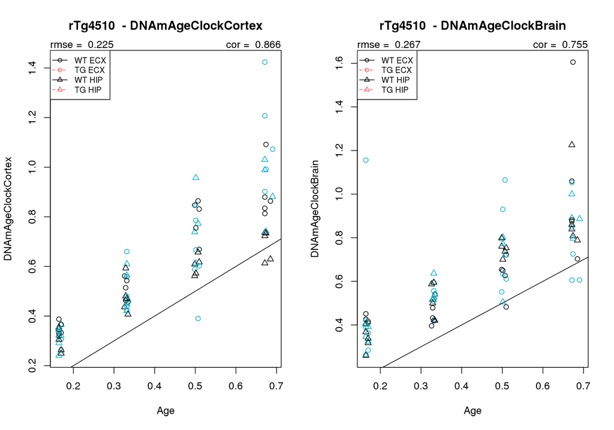

```r
## make a plot of actual age and DNAmAge for each type
clocks <- c("DNAmAgeClockCortex", "DNAmAgeClockBrain")


Model <- "rTg4510"
TG_colour <-"#00AEC9"

dat <- samplesheet[which(samplesheet$AD_model == Model),]
dat$Genotype <- factor(dat$Genotype, levels = c("WT","TG"))
dat$GenotypeCol <-  ifelse(dat$Genotype == "WT", "black", TG_colour)
dat$TissueCol <- ifelse(dat$Tissue == "CortexEntorhinalis", 1, 2)
## WT samples only
# plotWTSamples(dat, clocks, tissue = "", model = "rTg4510")

## all samples WT and TGs
model = "rTg4510"
tissue = ""
par(mfrow = c(1,2))
for(clock in clocks){
  corr <- cor(dat$Age, dat[, clock])
  err <- rmse(preds = dat[, clock], actuals = dat$Age)
  plot(dat$Age, dat[, clock], col = dat$GenotypeCol, pch = dat$TissueCol ,
       xlab = "Age", ylab = as.character(clock),
       main = paste(paste(model, tissue, sep = " "), clock, sep = " - "))
  mtext(paste("cor = ", signif(corr,3)), side = 3, adj = 1)
  mtext(paste("rmse = ", signif(err,3)), side = 3, adj = 0)
  abline(0,1)
  legend("topleft", legend=c("WT ECX", "TG ECX", "WT HIP", "TG HIP"),
       col=c("black","#FF5A62", "black","#FF5A62"),
       pch = c(1,1,2,2),
       lty=1:2, cex=0.8)
}
```

```r
kable(summary(lme(DNAmAgeClockCortex ~ Genotype + Age + Genotype*Age + Tissue, data=samplesheet, subset=AD_model=="rTg4510", random= ~1|MouseID))$tTable) %>%
  kable_styling() %>%
  scroll_box(width = "100%", height = "300px")
```

|  | Value | Std.Error | DF | t-value | p-value |
| --- | --- | --- | --- | --- | --- |
| (Intercept) | 0.2137722 | 0.0457810 | 39 | 4.669453 | 0.0000353 |
| GenotypeTG | -0.1154136 | 0.0623915 | 39 | -1.849830 | 0.0719261 |
| Age | 0.9438930 | 0.0954960 | 39 | 9.884106 | 0.0000000 |
| TissueHippocampus | -0.0641762 | 0.0258219 | 35 | -2.485343 | 0.0178687 |
| GenotypeTG:Age | 0.4099241 | 0.1366593 | 39 | 2.999607 | 0.0046915 |

```r
print("J20")
```

```
## [1] "J20"
```

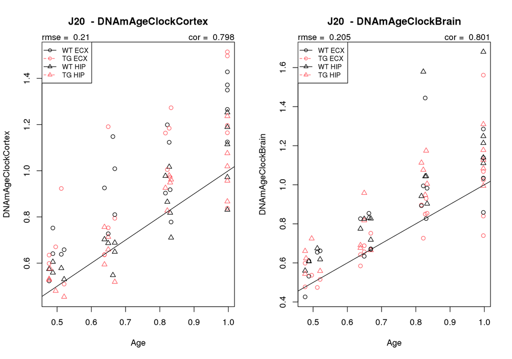

```r
## make a plot of actual age and DNAmAge for each type
clocks <- c("DNAmAgeClockCortex", "DNAmAgeClockBrain")


Model <- "J20"
TG_colour <-"#FF5A62"

dat <- samplesheet[which(samplesheet$AD_model == Model),]
dat$Genotype <- factor(dat$Genotype, levels = c("WT","TG"))
dat$GenotypeCol <-  ifelse(dat$Genotype == "WT", "black", TG_colour)
dat$TissueCol <- ifelse(dat$Tissue == "CortexEntorhinalis", 1, 2)
## WT samples only
# plotWTSamples(dat, clocks, tissue = "", model = "J20")

## all samples WT and TGs
model = "J20"
tissue = ""
par(mfrow = c(1,2))
for(clock in clocks){
  corr <- cor(dat$Age, dat[, clock])
  err <- rmse(preds = dat[, clock], actuals = dat$Age)
  plot(dat$Age, dat[, clock], col = dat$GenotypeCol, pch = dat$TissueCol ,
       xlab = "Age", ylab = as.character(clock),
       main = paste(paste(model, tissue, sep = " "), clock, sep = " - "))
  mtext(paste("cor = ", signif(corr,3)), side = 3, adj = 1)
  mtext(paste("rmse = ", signif(err,3)), side = 3, adj = 0)
  abline(0,1)
  legend("topleft", legend=c("WT ECX", "TG ECX", "WT HIP", "TG HIP"),
       col=c("black","#FF5A62", "black","#FF5A62"),
       pch = c(1,1,2,2),
       lty=1:2, cex=0.8)
}
```

```r
kable(summary(lme(DNAmAgeClockCortex ~ Genotype + Age + Genotype*Age + Tissue, data=samplesheet, subset=AD_model=="J20", random= ~1|MouseID))$tTable) %>%
  kable_styling() %>%
  scroll_box(width = "100%", height = "300px")
```

|  | Value | Std.Error | DF | t-value | p-value |
| --- | --- | --- | --- | --- | --- |
| (Intercept) | 0.1239657 | 0.1031348 | 38 | 1.2019775 | 0.2368094 |
| GenotypeTG | -0.0065837 | 0.1424994 | 37 | -0.0462016 | 0.9633981 |
| Age | 1.1302123 | 0.1331503 | 37 | 8.4882458 | 0.0000000 |
| TissueHippocampus | -0.1725517 | 0.0278244 | 38 | -6.2014561 | 0.0000003 |
| GenotypeTG:Age | 0.0026611 | 0.1862663 | 37 | 0.0142867 | 0.9886780 |

```r
print("rTg4510")
```

```
## [1] "rTg4510"
```

```r
kable(summary(lme(DNAmAgeClockCortex ~ Genotype + Age + Pathology + Tissue, na.action=na.omit, data=samplesheet, subset=AD_model=="rTg4510", random= ~1|MouseID))$tTable
) %>%
  kable_styling() %>%
  scroll_box(width = "100%", height = "300px")
```

|  | Value | Std.Error | DF | t-value | p-value |
| --- | --- | --- | --- | --- | --- |
| (Intercept) | 0.1741046 | 0.0409146 | 40 | 4.2553206 | 0.0001223 |
| GenotypeTG | 0.0033737 | 0.0351781 | 40 | 0.0959042 | 0.9240755 |
| Age | 1.0341823 | 0.0810520 | 40 | 12.7594947 | 0.0000000 |
| Pathology | 0.0036111 | 0.0024024 | 31 | 1.5031191 | 0.1429283 |
| TissueHippocampus | -0.0580722 | 0.0248923 | 31 | -2.3329397 | 0.0263155 |

```r
print("J20")
```

```
## [1] "J20"
```

```r
kable(summary(lme(DNAmAgeClockCortex ~ Genotype + Age + Pathology + Tissue, na.action=na.omit, data=samplesheet, subset=AD_model=="J20", random= ~1|MouseID))$tTable) %>%
  kable_styling() %>%
  scroll_box(width = "100%", height = "300px")
```

|  | Value | Std.Error | DF | t-value | p-value |
| --- | --- | --- | --- | --- | --- |
| (Intercept) | 0.1185607 | 0.0814952 | 38 | 1.4548182 | 0.1539309 |
| GenotypeTG | -0.0007917 | 0.0395902 | 38 | -0.0199978 | 0.9841498 |
| Age | 1.1364177 | 0.0978501 | 38 | 11.6138587 | 0.0000000 |
| Pathology | -0.0007942 | 0.0050265 | 36 | -0.1580001 | 0.8753397 |
| TissueHippocampus | -0.1709779 | 0.0337262 | 36 | -5.0695854 | 0.0000121 |

The other way to combine the two datasets is to pool together AD models as the biggest difference is tissue differences. Furthermore, the clocks are tissue dependents and genotype for WT and TG will also be different regardless of pathology. Combining the models will also provide a larger age range.

### By model

$${DNAmAgeClockCortex } = {Genotype + Age + Genotype*Age + AD model }$$

$${DNAmAgeClockCortex } = {Genotype + Age + Pathology + AD model }$$

Entorhinal Cortex

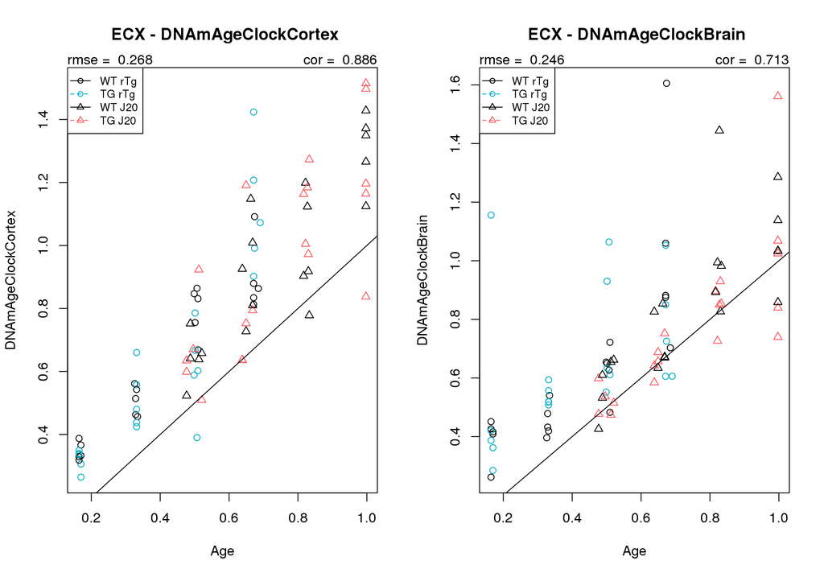

```r
## make a plot of actual age and DNAmAge for each type
clocks <- c("DNAmAgeClockCortex", "DNAmAgeClockBrain")


Tissue <- "CortexEntorhinalis"
TG_colour <- "purple"

dat <- samplesheet[which(samplesheet$Tissue == Tissue),]
dat$Genotype <- factor(dat$Genotype, levels = c("WT","TG"))

## WT samples only
# plotWTSamples(dat, clocks, tissue = "ECX", model = "")

dat1 <-dat[which(dat$AD_model == "rTg4510"),]
dat1$GenoCol <- ifelse(dat1$Genotype == "WT", "black", "#00AEC9")
dat1$ModelShape <- rep(1, nrow(dat1))

dat2 <-dat[which(dat$AD_model == "J20"),]
dat2$GenoCol <- ifelse(dat2$Genotype == "WT", "black", "#FF5A62")
dat2$ModelShape <- rep(2, nrow(dat2))
dat <- rbind(dat1, dat2)

#Plots for TGs and WTs samples
model = ""
tissue = "ECX"
par(mfrow = c(1,2))
for(clock in clocks){
  corr <- cor(dat$Age, dat[, clock])
  err <- rmse(preds = dat[, clock], actuals = dat$Age)
  plot(dat$Age, dat[, clock], col = dat$GenoCol,pch = dat$ModelShape,
       xlab = "Age", ylab = as.character(clock),
       main = paste(paste(model, tissue, sep = " "), clock, sep = " - "))
  mtext(paste("cor = ", signif(corr,3)), side = 3, adj = 1)
  mtext(paste("rmse = ", signif(err,3)), side = 3, adj = 0)
  abline(0,1)

  legend("topleft", legend=c("WT rTg", "TG rTg", "WT J20", "TG J20"),
       col=c("black","#00AEC9", "black","#FF5A62"),
       pch = c(1,1,2,2),
       lty=1:2, cex=0.8)
}
```

```r
## all samples WT and TGs
# plotSamples(dat, clocks, tissue = "ECX", model = "")


kable(summary(lme(DNAmAgeClockCortex ~ Genotype + Age +  Genotype*Age + AD_model, na.action=na.omit, data=samplesheet, subset=Tissue=="CortexEntorhinalis", random= ~1|MouseID))$tTable
) %>%
  kable_styling() %>%
  scroll_box(width = "100%", height = "300px")
```

|  | Value | Std.Error | DF | t-value | p-value |
| --- | --- | --- | --- | --- | --- |
| (Intercept) | 0.0455194 | 0.0826511 | 75 | 0.5507416 | 0.5834476 |
| GenotypeTG | -0.0493341 | 0.0857404 | 75 | -0.5753896 | 0.5667502 |
| Age | 1.2232179 | 0.1121869 | 75 | 10.9033937 | 0.0000000 |
| AD_modelrTg4510 | 0.0864558 | 0.0444616 | 75 | 1.9445033 | 0.0555847 |
| GenotypeTG:Age | 0.0840136 | 0.1356204 | 75 | 0.6194762 | 0.5374801 |

```r
kable(summary(lme(DNAmAgeClockCortex ~ Genotype + Age +  Pathology + AD_model, na.action=na.omit, data=samplesheet, subset=Tissue=="CortexEntorhinalis", random= ~1|MouseID))$tTable
) %>%
  kable_styling() %>%
  scroll_box(width = "100%", height = "300px")
```

|  | Value | Std.Error | DF | t-value | p-value |
| --- | --- | --- | --- | --- | --- |
| (Intercept) | 0.0185070 | 0.0765970 | 71 | 0.2416149 | 0.8097750 |
| GenotypeTG | 0.0130868 | 0.0387750 | 71 | 0.3375074 | 0.7367302 |
| Age | 1.2627621 | 0.0909239 | 71 | 13.8881154 | 0.0000000 |
| Pathology | -0.0058425 | 0.0045620 | 71 | -1.2806683 | 0.2044780 |
| AD_modelrTg4510 | 0.1012074 | 0.0525950 | 71 | 1.9242774 | 0.0583281 |

Hippocampus

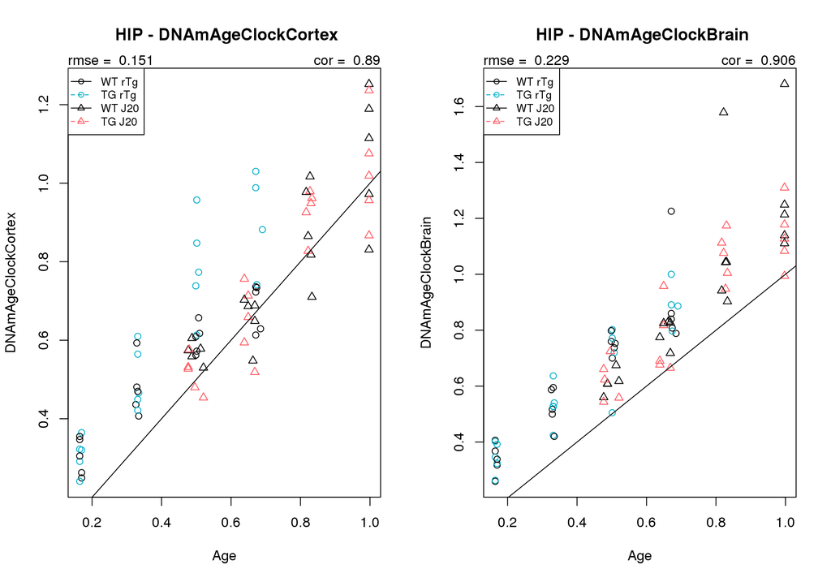

```r
## make a plot of actual age and DNAmAge for each type
clocks <- c("DNAmAgeClockCortex", "DNAmAgeClockBrain" )


Tissue <- "Hippocampus"
TG_colour <- "purple"

dat <- samplesheet[which(samplesheet$Tissue == Tissue),]
dat$Genotype <- factor(dat$Genotype, levels = c("WT","TG"))
dat$GenotypeCol <-  ifelse(dat$Genotype == "WT", "black", TG_colour)

## WT samples only
# plotWTSamples(dat, clocks, tissue = "HIP", model = "")

dat1 <-dat[which(dat$AD_model == "rTg4510"),]
dat1$GenoCol <- ifelse(dat1$Genotype == "WT", "black", "#00AEC9")
dat1$ModelShape <- rep(1, nrow(dat1))

dat2 <-dat[which(dat$AD_model == "J20"),]
dat2$GenoCol <- ifelse(dat2$Genotype == "WT", "black", "#FF5A62")
dat2$ModelShape <- rep(2, nrow(dat2))
dat <- rbind(dat1, dat2)

#Plots for TGs and WTs samples
model = ""
tissue = "HIP"
par(mfrow = c(1,2))
for(clock in clocks){
  corr <- cor(dat$Age, dat[, clock])
  err <- rmse(preds = dat[, clock], actuals = dat$Age)
  plot(dat$Age, dat[, clock], col = dat$GenoCol,pch = dat$ModelShape,
       xlab = "Age", ylab = as.character(clock),
       main = paste(paste(model, tissue, sep = " "), clock, sep = " - "))
  mtext(paste("cor = ", signif(corr,3)), side = 3, adj = 1)
  mtext(paste("rmse = ", signif(err,3)), side = 3, adj = 0)
  abline(0,1)

  legend("topleft", legend=c("WT rTg", "TG rTg", "WT J20", "TG J20"),
       col=c("black","#00AEC9", "black","#FF5A62"),
       pch = c(1,1,2,2),
       lty=1:2, cex=0.8)


}
```

```r
kable(summary(lme(DNAmAgeClockCortex ~ Genotype + Age +  Genotype*Age + AD_model, na.action=na.omit, data=samplesheet, subset=Tissue=="Hippocampus", random= ~1|MouseID))$tTable
) %>%
  kable_styling() %>%
  scroll_box(width = "100%", height = "300px")
```

|  | Value | Std.Error | DF | t-value | p-value |
| --- | --- | --- | --- | --- | --- |
| (Intercept) | 0.0084923 | 0.0570554 | 74 | 0.1488433 | 0.8820822 |
| GenotypeTG | 0.0500539 | 0.0586781 | 74 | 0.8530257 | 0.3963977 |
| Age | 1.0164642 | 0.0772269 | 74 | 13.1620533 | 0.0000000 |
| AD_modelrTg4510 | 0.1122900 | 0.0309611 | 74 | 3.6268041 | 0.0005245 |
| GenotypeTG:Age | -0.0034636 | 0.0929640 | 74 | -0.0372572 | 0.9703802 |

```r
kable(summary(lme(DNAmAgeClockCortex ~ Genotype + Age +  Pathology + AD_model, na.action=na.omit, data=samplesheet, subset=Tissue=="Hippocampus", random= ~1|MouseID))$tTable
) %>%
  kable_styling() %>%
  scroll_box(width = "100%", height = "300px")
```

|  | Value | Std.Error | DF | t-value | p-value |
| --- | --- | --- | --- | --- | --- |
| (Intercept) | 0.1383871 | 0.0558448 | 74 | 2.478066 | 0.0154903 |
| GenotypeTG | -0.0308672 | 0.0288767 | 74 | -1.068931 | 0.2885751 |
| Age | 0.8527026 | 0.0691380 | 74 | 12.333347 | 0.0000000 |
| Pathology | 0.0085316 | 0.0021307 | 74 | 4.004186 | 0.0001465 |
| AD_modelrTg4510 | 0.0425768 | 0.0330307 | 74 | 1.289006 | 0.2014111 |

```r
print("DNAmAgeClockBrain")
```

```
## [1] "DNAmAgeClockBrain"
```

```r
kable(summary(lme(DNAmAgeClockBrain ~ Genotype + Age +  Genotype*Age + AD_model, na.action=na.omit, data=samplesheet, subset=Tissue=="Hippocampus", random= ~1|MouseID))$tTable
) %>%
  kable_styling() %>%
  scroll_box(width = "100%", height = "300px")
```

|  | Value | Std.Error | DF | t-value | p-value |
| --- | --- | --- | --- | --- | --- |
| (Intercept) | 0.0259962 | 0.0670053 | 74 | 0.3879730 | 0.6991498 |
| GenotypeTG | 0.0593071 | 0.0689109 | 74 | 0.8606344 | 0.3922193 |
| Age | 1.2405764 | 0.0906944 | 74 | 13.6786411 | 0.0000000 |
| AD_modelrTg4510 | 0.0815854 | 0.0363604 | 74 | 2.2437955 | 0.0278371 |
| GenotypeTG:Age | -0.1481056 | 0.1091760 | 74 | -1.3565768 | 0.1790400 |

```r
kable(summary(lme(DNAmAgeClockBrain ~ Genotype + Age +  Pathology + AD_model, na.action=na.omit, data=samplesheet, subset=Tissue=="Hippocampus", random= ~1|MouseID))$tTable
) %>%
  kable_styling() %>%
  scroll_box(width = "100%", height = "300px")
```

|  | Value | Std.Error | DF | t-value | p-value |
| --- | --- | --- | --- | --- | --- |
| (Intercept) | 0.0719526 | 0.0732310 | 74 | 0.9825429 | 0.3290340 |
| GenotypeTG | -0.0284366 | 0.0378668 | 74 | -0.7509646 | 0.4550554 |
| Age | 1.1628958 | 0.0906627 | 74 | 12.8266180 | 0.0000000 |
| Pathology | 0.0002090 | 0.0027940 | 74 | 0.0747948 | 0.9405798 |
| AD_modelrTg4510 | 0.0799968 | 0.0433142 | 74 | 1.8468981 | 0.0687598 |

## Age*Age

We look at each tissue and model.

ECX rTg4510

```r
kable(summary(lm(DNAmAgeClockCortex ~ Age*Age, data=samplesheet[which(samplesheet$Tissue=="CortexEntorhinalis" & samplesheet$AD_model=="rTg4510"),]))$coef
) %>%
  kable_styling() %>%
  scroll_box(width = "100%", height = "150px")
```

|  | Estimate | Std. Error | t value | Pr(>\|t\|) |
| --- | --- | --- | --- | --- |
| (Intercept) | 0.0918154 | 0.0499018 | 1.83992 | 0.0736011 |
| Age | 1.3021984 | 0.1084251 | 12.01012 | 0.0000000 |

HIP rTg4510

```r
kable(summary(lm(DNAmAgeClockCortex ~ Age*Age, data=samplesheet[which(samplesheet$Tissue=="Hippocampus" & samplesheet$AD_model=="rTg4510"),]))$coef
) %>%
  kable_styling() %>%
  scroll_box(width = "100%", height = "150px")
```

|  | Estimate | Std. Error | t value | Pr(>\|t\|) |
| --- | --- | --- | --- | --- |
| (Intercept) | 0.1623534 | 0.0416421 | 3.89878 | 0.0003923 |
| Age | 0.9731199 | 0.0919155 | 10.58712 | 0.0000000 |

ECX J20

```r
kable(summary(lm(DNAmAgeClockCortex ~ Age*Age, data=samplesheet[which(samplesheet$Tissue=="CortexEntorhinalis" & samplesheet$AD_model=="J20"),]))$coef
) %>%
  kable_styling() %>%
  scroll_box(width = "100%", height = "150px")
```

|  | Estimate | Std. Error | t value | Pr(>\|t\|) |
| --- | --- | --- | --- | --- |
| (Intercept) | 0.0489863 | 0.1082849 | 0.4523834 | 0.6535649 |
| Age | 1.2273048 | 0.1412683 | 8.6877582 | 0.0000000 |

HIP J20

```r
kable(summary(lm(DNAmAgeClockCortex ~ Age*Age, data=samplesheet[which(samplesheet$Tissue=="Hippocampus" & samplesheet$AD_model=="J20"),]))$coef
) %>%
  kable_styling() %>%
  scroll_box(width = "100%", height = "150px")
```

|  | Estimate | Std. Error | t value | Pr(>\|t\|) |
| --- | --- | --- | --- | --- |
| (Intercept) | 0.0077619 | 0.0661194 | 0.1173916 | 0.907168 |
| Age | 1.0494319 | 0.0863191 | 12.1575881 | 0.000000 |